# DBnomics R client

Thomas Brand[^1], Sébastien Galais[^2]

# 1 DBnomics : the world’s economic database

[figure not shown]

# 2 Fetch time series by `ids`

First, let’s assume that we know which series we want to download. A series identifier (`ids`) is defined by three values, formatted like this: `provider_code`/`dataset_code`/`series_code`.

## 2.1 Fetch one series from dataset ‘Unemployment rate’ (ZUTN) of AMECO provider

```r
library(magrittr)
library(dplyr)
library(ggplot2)
library(rdbnomics)
```

```r
df <- rdb(ids = 'AMECO/ZUTN/EA19.1.0.0.0.ZUTN') %>%
  filter(!is.na(value))
```

In such data.frame, you will always find at least nine columns:

- `provider_code`
- `dataset_code`
- `dataset_name`
- `series_code`
- `series_name`
- `original_period` (character string)
- `period` (date of the first day of `original_period`)
- `value`
- `@frequency` (harmonized frequency generated by DBnomics)

The other columns depend on the provider and on the dataset. They always come in pairs (for the code and the name). In the data.frame `df`, you have:

| provider_code | dataset_code | dataset_name | series_code | series_name | original_period | period | value | @frequency | unit | geo | freq | indexed_at |
| --- | --- | --- | --- | --- | --- | --- | --- | --- | --- | --- | --- | --- |
| AMECO | ZUTN | Unemployment rate: total :- Member States: definition EUROSTAT | EA19.1.0.0.0.ZUTN | Annually – (Percentage of active population) – Euro area | 1998 | 1998-01-01 | 10.4 | annual | percentage-of-active-population | ea19 | a | 2019-01-08T10:11:38Z |
| AMECO | ZUTN | Unemployment rate: total :- Member States: definition EUROSTAT | EA19.1.0.0.0.ZUTN | Annually – (Percentage of active population) – Euro area | 1999 | 1999-01-01 | 9.7 | annual | percentage-of-active-population | ea19 | a | 2019-01-08T10:11:38Z |
| AMECO | ZUTN | Unemployment rate: total :- Member States: definition EUROSTAT | EA19.1.0.0.0.ZUTN | Annually – (Percentage of active population) – Euro area | 2000 | 2000-01-01 | 8.9 | annual | percentage-of-active-population | ea19 | a | 2019-01-08T10:11:38Z |
| AMECO | ZUTN | Unemployment rate: total :- Member States: definition EUROSTAT | EA19.1.0.0.0.ZUTN | Annually – (Percentage of active population) – Euro area | 2001 | 2001-01-01 | 8.3 | annual | percentage-of-active-population | ea19 | a | 2019-01-08T10:11:38Z |
| AMECO | ZUTN | Unemployment rate: total :- Member States: definition EUROSTAT | EA19.1.0.0.0.ZUTN | Annually – (Percentage of active population) – Euro area | 2002 | 2002-01-01 | 8.6 | annual | percentage-of-active-population | ea19 | a | 2019-01-08T10:11:38Z |
| AMECO | ZUTN | Unemployment rate: total :- Member States: definition EUROSTAT | EA19.1.0.0.0.ZUTN | Annually – (Percentage of active population) – Euro area | 2003 | 2003-01-01 | 9.1 | annual | percentage-of-active-population | ea19 | a | 2019-01-08T10:11:38Z |
| AMECO | ZUTN | Unemployment rate: total :- Member States: definition EUROSTAT | EA19.1.0.0.0.ZUTN | Annually – (Percentage of active population) – Euro area | 2004 | 2004-01-01 | 9.3 | annual | percentage-of-active-population | ea19 | a | 2019-01-08T10:11:38Z |
| AMECO | ZUTN | Unemployment rate: total :- Member States: definition EUROSTAT | EA19.1.0.0.0.ZUTN | Annually – (Percentage of active population) – Euro area | 2005 | 2005-01-01 | 9.1 | annual | percentage-of-active-population | ea19 | a | 2019-01-08T10:11:38Z |
| AMECO | ZUTN | Unemployment rate: total :- Member States: definition EUROSTAT | EA19.1.0.0.0.ZUTN | Annually – (Percentage of active population) – Euro area | 2006 | 2006-01-01 | 8.4 | annual | percentage-of-active-population | ea19 | a | 2019-01-08T10:11:38Z |
| AMECO | ZUTN | Unemployment rate: total :- Member States: definition EUROSTAT | EA19.1.0.0.0.ZUTN | Annually – (Percentage of active population) – Euro area | 2007 | 2007-01-01 | 7.5 | annual | percentage-of-active-population | ea19 | a | 2019-01-08T10:11:38Z |

[output cut: 13 more lines]

[figure not shown]

```r
ggplot(df, aes(x = period, y = value, color = series_code)) +
  geom_line(size = 2) +
  dbnomics()
```

## 2.2 Fetch two series from dataset ‘Unemployment rate’ (ZUTN) of AMECO provider

```r
df <- rdb(ids = c('AMECO/ZUTN/EA19.1.0.0.0.ZUTN', 'AMECO/ZUTN/DNK.1.0.0.0.ZUTN')) %>%
  filter(!is.na(value))
```

| provider_code | dataset_code | dataset_name | series_code | series_name | original_period | period | value | @frequency | unit | geo | freq | indexed_at |
| --- | --- | --- | --- | --- | --- | --- | --- | --- | --- | --- | --- | --- |
| AMECO | ZUTN | Unemployment rate: total :- Member States: definition EUROSTAT | DNK.1.0.0.0.ZUTN | Annually – (Percentage of active population) – Denmark | 1960 | 1960-01-01 | 2 | annual | percentage-of-active-population | dnk | a | 2019-01-08T10:11:38Z |
| AMECO | ZUTN | Unemployment rate: total :- Member States: definition EUROSTAT | DNK.1.0.0.0.ZUTN | Annually – (Percentage of active population) – Denmark | 1961 | 1961-01-01 | 1.6 | annual | percentage-of-active-population | dnk | a | 2019-01-08T10:11:38Z |
| AMECO | ZUTN | Unemployment rate: total :- Member States: definition EUROSTAT | DNK.1.0.0.0.ZUTN | Annually – (Percentage of active population) – Denmark | 1962 | 1962-01-01 | 1.4 | annual | percentage-of-active-population | dnk | a | 2019-01-08T10:11:38Z |
| AMECO | ZUTN | Unemployment rate: total :- Member States: definition EUROSTAT | DNK.1.0.0.0.ZUTN | Annually – (Percentage of active population) – Denmark | 1963 | 1963-01-01 | 2 | annual | percentage-of-active-population | dnk | a | 2019-01-08T10:11:38Z |
| AMECO | ZUTN | Unemployment rate: total :- Member States: definition EUROSTAT | DNK.1.0.0.0.ZUTN | Annually – (Percentage of active population) – Denmark | 1964 | 1964-01-01 | 1.2 | annual | percentage-of-active-population | dnk | a | 2019-01-08T10:11:38Z |
| AMECO | ZUTN | Unemployment rate: total :- Member States: definition EUROSTAT | DNK.1.0.0.0.ZUTN | Annually – (Percentage of active population) – Denmark | 1965 | 1965-01-01 | 0.9 | annual | percentage-of-active-population | dnk | a | 2019-01-08T10:11:38Z |
| AMECO | ZUTN | Unemployment rate: total :- Member States: definition EUROSTAT | DNK.1.0.0.0.ZUTN | Annually – (Percentage of active population) – Denmark | 1966 | 1966-01-01 | 1.1 | annual | percentage-of-active-population | dnk | a | 2019-01-08T10:11:38Z |
| AMECO | ZUTN | Unemployment rate: total :- Member States: definition EUROSTAT | DNK.1.0.0.0.ZUTN | Annually – (Percentage of active population) – Denmark | 1967 | 1967-01-01 | 1 | annual | percentage-of-active-population | dnk | a | 2019-01-08T10:11:38Z |
| AMECO | ZUTN | Unemployment rate: total :- Member States: definition EUROSTAT | DNK.1.0.0.0.ZUTN | Annually – (Percentage of active population) – Denmark | 1968 | 1968-01-01 | 1 | annual | percentage-of-active-population | dnk | a | 2019-01-08T10:11:38Z |
| AMECO | ZUTN | Unemployment rate: total :- Member States: definition EUROSTAT | DNK.1.0.0.0.ZUTN | Annually – (Percentage of active population) – Denmark | 1969 | 1969-01-01 | 0.9 | annual | percentage-of-active-population | dnk | a | 2019-01-08T10:11:38Z |

[output cut: 74 more lines]

[figure not shown]

```r
ggplot(df, aes(x = period, y = value, color = series_code)) +
  geom_line(size = 2) +
  dbnomics()
```

## 2.3 Fetch two series from different datasets of different providers

```r
df <- rdb(ids = c('AMECO/ZUTN/EA19.1.0.0.0.ZUTN', 'Eurostat/une_rt_q/Q.SA.TOTAL.PC_ACT.T.EA19')) %>%
  filter(!is.na(value))
```

| provider_code | dataset_code | dataset_name | series_code | series_name | original_period | period | value | @frequency | unit | geo | freq | indexed_at | observations_attributes | FREQ | age | s_adj | sex |
| --- | --- | --- | --- | --- | --- | --- | --- | --- | --- | --- | --- | --- | --- | --- | --- | --- | --- |
| AMECO | ZUTN | Unemployment rate: total :- Member States: definition EUROSTAT | EA19.1.0.0.0.ZUTN | Annually – (Percentage of active population) – Euro area | 1998 | 1998-01-01 | 10.4 | annual | percentage-of-active-population | ea19 | a | 2019-01-08T10:11:38Z |  |  |  |  |  |
| AMECO | ZUTN | Unemployment rate: total :- Member States: definition EUROSTAT | EA19.1.0.0.0.ZUTN | Annually – (Percentage of active population) – Euro area | 1999 | 1999-01-01 | 9.7 | annual | percentage-of-active-population | ea19 | a | 2019-01-08T10:11:38Z |  |  |  |  |  |
| AMECO | ZUTN | Unemployment rate: total :- Member States: definition EUROSTAT | EA19.1.0.0.0.ZUTN | Annually – (Percentage of active population) – Euro area | 2000 | 2000-01-01 | 8.9 | annual | percentage-of-active-population | ea19 | a | 2019-01-08T10:11:38Z |  |  |  |  |  |
| AMECO | ZUTN | Unemployment rate: total :- Member States: definition EUROSTAT | EA19.1.0.0.0.ZUTN | Annually – (Percentage of active population) – Euro area | 2001 | 2001-01-01 | 8.3 | annual | percentage-of-active-population | ea19 | a | 2019-01-08T10:11:38Z |  |  |  |  |  |
| AMECO | ZUTN | Unemployment rate: total :- Member States: definition EUROSTAT | EA19.1.0.0.0.ZUTN | Annually – (Percentage of active population) – Euro area | 2002 | 2002-01-01 | 8.6 | annual | percentage-of-active-population | ea19 | a | 2019-01-08T10:11:38Z |  |  |  |  |  |
| AMECO | ZUTN | Unemployment rate: total :- Member States: definition EUROSTAT | EA19.1.0.0.0.ZUTN | Annually – (Percentage of active population) – Euro area | 2003 | 2003-01-01 | 9.1 | annual | percentage-of-active-population | ea19 | a | 2019-01-08T10:11:38Z |  |  |  |  |  |
| AMECO | ZUTN | Unemployment rate: total :- Member States: definition EUROSTAT | EA19.1.0.0.0.ZUTN | Annually – (Percentage of active population) – Euro area | 2004 | 2004-01-01 | 9.3 | annual | percentage-of-active-population | ea19 | a | 2019-01-08T10:11:38Z |  |  |  |  |  |
| AMECO | ZUTN | Unemployment rate: total :- Member States: definition EUROSTAT | EA19.1.0.0.0.ZUTN | Annually – (Percentage of active population) – Euro area | 2005 | 2005-01-01 | 9.1 | annual | percentage-of-active-population | ea19 | a | 2019-01-08T10:11:38Z |  |  |  |  |  |
| AMECO | ZUTN | Unemployment rate: total :- Member States: definition EUROSTAT | EA19.1.0.0.0.ZUTN | Annually – (Percentage of active population) – Euro area | 2006 | 2006-01-01 | 8.4 | annual | percentage-of-active-population | ea19 | a | 2019-01-08T10:11:38Z |  |  |  |  |  |
| AMECO | ZUTN | Unemployment rate: total :- Member States: definition EUROSTAT | EA19.1.0.0.0.ZUTN | Annually – (Percentage of active population) – Euro area | 2007 | 2007-01-01 | 7.5 | annual | percentage-of-active-population | ea19 | a | 2019-01-08T10:11:38Z |  |  |  |  |  |

[output cut: 95 more lines]

[figure not shown]

```r
ggplot(df, aes(x = period, y = value, color = series_code)) +
  geom_line(size = 2) +
  dbnomics()
```

# 3 Fetch time series by `mask`

The code mask notation is a very concise way to select one or many time series at once. It is compatible only with some providers : BIS, ECB, Eurostat, FED, ILO, IMF, INSEE, OECD, WTO.

## 3.1 Fetch one series from dataset ‘Consumer Price Index’ (CPI) of IMF

```r
df <- rdb('IMF', 'CPI', mask = 'M.DE.PCPIEC_WT') %>%
  filter(!is.na(value))
```

| provider_code | dataset_code | dataset_name | series_code | series_name | original_period | period | value | @frequency | indexed_at | FREQ | INDICATOR | REF_AREA |
| --- | --- | --- | --- | --- | --- | --- | --- | --- | --- | --- | --- | --- |
| IMF | CPI | Consumer Price Index (CPI) | M.DE.PCPIEC_WT | Monthly – Germany – Communication, Weight | 1996-01 | 1996-01-01 | 22.66 | monthly | 2019-01-09T03:38:54Z | M | PCPIEC_WT | DE |
| IMF | CPI | Consumer Price Index (CPI) | M.DE.PCPIEC_WT | Monthly – Germany – Communication, Weight | 1996-02 | 1996-02-01 | 22.66 | monthly | 2019-01-09T03:38:54Z | M | PCPIEC_WT | DE |
| IMF | CPI | Consumer Price Index (CPI) | M.DE.PCPIEC_WT | Monthly – Germany – Communication, Weight | 1996-03 | 1996-03-01 | 22.66 | monthly | 2019-01-09T03:38:54Z | M | PCPIEC_WT | DE |
| IMF | CPI | Consumer Price Index (CPI) | M.DE.PCPIEC_WT | Monthly – Germany – Communication, Weight | 1996-04 | 1996-04-01 | 22.66 | monthly | 2019-01-09T03:38:54Z | M | PCPIEC_WT | DE |
| IMF | CPI | Consumer Price Index (CPI) | M.DE.PCPIEC_WT | Monthly – Germany – Communication, Weight | 1996-05 | 1996-05-01 | 22.66 | monthly | 2019-01-09T03:38:54Z | M | PCPIEC_WT | DE |
| IMF | CPI | Consumer Price Index (CPI) | M.DE.PCPIEC_WT | Monthly – Germany – Communication, Weight | 1996-06 | 1996-06-01 | 22.66 | monthly | 2019-01-09T03:38:54Z | M | PCPIEC_WT | DE |
| IMF | CPI | Consumer Price Index (CPI) | M.DE.PCPIEC_WT | Monthly – Germany – Communication, Weight | 1996-07 | 1996-07-01 | 22.66 | monthly | 2019-01-09T03:38:54Z | M | PCPIEC_WT | DE |
| IMF | CPI | Consumer Price Index (CPI) | M.DE.PCPIEC_WT | Monthly – Germany – Communication, Weight | 1996-08 | 1996-08-01 | 22.66 | monthly | 2019-01-09T03:38:54Z | M | PCPIEC_WT | DE |
| IMF | CPI | Consumer Price Index (CPI) | M.DE.PCPIEC_WT | Monthly – Germany – Communication, Weight | 1996-09 | 1996-09-01 | 22.66 | monthly | 2019-01-09T03:38:54Z | M | PCPIEC_WT | DE |
| IMF | CPI | Consumer Price Index (CPI) | M.DE.PCPIEC_WT | Monthly – Germany – Communication, Weight | 1996-10 | 1996-10-01 | 22.66 | monthly | 2019-01-09T03:38:54Z | M | PCPIEC_WT | DE |

[output cut: 265 more lines]

[figure not shown]

```r
ggplot(df, aes(x = period, y = value, color = series_code)) +
  geom_step(size = 2) +
  dbnomics()
```

## 3.2 Fetch two series from dataset ‘Consumer Price Index’ (CPI) of IMF

You just have to add a `+` between two different values of a dimension.

```r
df <- rdb('IMF', 'CPI', mask = 'M.DE+FR.PCPIEC_WT') %>%
  filter(!is.na(value))
```

| provider_code | dataset_code | dataset_name | series_code | series_name | original_period | period | value | @frequency | indexed_at | FREQ | INDICATOR | REF_AREA |
| --- | --- | --- | --- | --- | --- | --- | --- | --- | --- | --- | --- | --- |
| IMF | CPI | Consumer Price Index (CPI) | M.DE.PCPIEC_WT | Monthly – Germany – Communication, Weight | 1996-01 | 1996-01-01 | 22.66 | monthly | 2019-01-09T03:38:54Z | M | PCPIEC_WT | DE |
| IMF | CPI | Consumer Price Index (CPI) | M.DE.PCPIEC_WT | Monthly – Germany – Communication, Weight | 1996-02 | 1996-02-01 | 22.66 | monthly | 2019-01-09T03:38:54Z | M | PCPIEC_WT | DE |
| IMF | CPI | Consumer Price Index (CPI) | M.DE.PCPIEC_WT | Monthly – Germany – Communication, Weight | 1996-03 | 1996-03-01 | 22.66 | monthly | 2019-01-09T03:38:54Z | M | PCPIEC_WT | DE |
| IMF | CPI | Consumer Price Index (CPI) | M.DE.PCPIEC_WT | Monthly – Germany – Communication, Weight | 1996-04 | 1996-04-01 | 22.66 | monthly | 2019-01-09T03:38:54Z | M | PCPIEC_WT | DE |
| IMF | CPI | Consumer Price Index (CPI) | M.DE.PCPIEC_WT | Monthly – Germany – Communication, Weight | 1996-05 | 1996-05-01 | 22.66 | monthly | 2019-01-09T03:38:54Z | M | PCPIEC_WT | DE |
| IMF | CPI | Consumer Price Index (CPI) | M.DE.PCPIEC_WT | Monthly – Germany – Communication, Weight | 1996-06 | 1996-06-01 | 22.66 | monthly | 2019-01-09T03:38:54Z | M | PCPIEC_WT | DE |
| IMF | CPI | Consumer Price Index (CPI) | M.DE.PCPIEC_WT | Monthly – Germany – Communication, Weight | 1996-07 | 1996-07-01 | 22.66 | monthly | 2019-01-09T03:38:54Z | M | PCPIEC_WT | DE |
| IMF | CPI | Consumer Price Index (CPI) | M.DE.PCPIEC_WT | Monthly – Germany – Communication, Weight | 1996-08 | 1996-08-01 | 22.66 | monthly | 2019-01-09T03:38:54Z | M | PCPIEC_WT | DE |
| IMF | CPI | Consumer Price Index (CPI) | M.DE.PCPIEC_WT | Monthly – Germany – Communication, Weight | 1996-09 | 1996-09-01 | 22.66 | monthly | 2019-01-09T03:38:54Z | M | PCPIEC_WT | DE |
| IMF | CPI | Consumer Price Index (CPI) | M.DE.PCPIEC_WT | Monthly – Germany – Communication, Weight | 1996-10 | 1996-10-01 | 22.66 | monthly | 2019-01-09T03:38:54Z | M | PCPIEC_WT | DE |

[output cut: 552 more lines]

[figure not shown]

```r
ggplot(df, aes(x = period, y = value, color = series_code)) +
  geom_step(size = 2) +
  dbnomics()
```

## 3.3 Fetch all series along one dimension from dataset ‘Consumer Price Index’ (CPI) of IMF

```r
df <- rdb('IMF', 'CPI', mask = 'M..PCPIEC_WT') %>%
  filter(!is.na(value)) %>%
  arrange(desc(period), REF_AREA) %>%
  head(100)
```

| provider_code | dataset_code | dataset_name | series_code | series_name | original_period | period | value | @frequency | indexed_at | observations_attributes | FREQ | INDICATOR | REF_AREA |
| --- | --- | --- | --- | --- | --- | --- | --- | --- | --- | --- | --- | --- | --- |
| IMF | CPI | Consumer Price Index (CPI) | M.BE.PCPIEC_WT | Monthly – Belgium – Communication, Weight | 2018-12 | 2018-12-01 | 42.56384 | monthly | 2019-01-09T03:38:54Z |  | M | PCPIEC_WT | BE |
| IMF | CPI | Consumer Price Index (CPI) | M.CY.PCPIEC_WT | Monthly – Cyprus – Communication, Weight | 2018-12 | 2018-12-01 | 439 | monthly | 2019-01-09T03:38:54Z |  | M | PCPIEC_WT | CY |
| IMF | CPI | Consumer Price Index (CPI) | M.IS.PCPIEC_WT | Monthly – Iceland – Communication, Weight | 2018-12 | 2018-12-01 | 23 | monthly | 2019-01-09T03:38:54Z |  | M | PCPIEC_WT | IS |
| IMF | CPI | Consumer Price Index (CPI) | M.PY.PCPIEC_WT | Monthly – Paraguay – Communication, Weight | 2018-12 | 2018-12-01 | 4 | monthly | 2019-01-09T03:38:54Z |  | M | PCPIEC_WT | PY |
| IMF | CPI | Consumer Price Index (CPI) | M.AE.PCPIEC_WT | Monthly – United Arab Emirates – Communication, Weight | 2018-11 | 2018-11-01 | 0.0540910138 | monthly | 2019-01-09T03:38:54Z |  | M | PCPIEC_WT | AE |
| IMF | CPI | Consumer Price Index (CPI) | M.AO.PCPIEC_WT | Monthly – Angola – Communication, Weight | 2018-11 | 2018-11-01 | 3.3275683613 | monthly | 2019-01-09T03:38:54Z |  | M | PCPIEC_WT | AO |
| IMF | CPI | Consumer Price Index (CPI) | M.AT.PCPIEC_WT | Monthly – Austria – Communication, Weight | 2018-11 | 2018-11-01 | 19.7618 | monthly | 2019-01-09T03:38:54Z |  | M | PCPIEC_WT | AT |
| IMF | CPI | Consumer Price Index (CPI) | M.BE.PCPIEC_WT | Monthly – Belgium – Communication, Weight | 2018-11 | 2018-11-01 | 42.56384 | monthly | 2019-01-09T03:38:54Z |  | M | PCPIEC_WT | BE |
| IMF | CPI | Consumer Price Index (CPI) | M.BG.PCPIEC_WT | Monthly – Bulgaria – Communication, Weight | 2018-11 | 2018-11-01 | 5.2621394591 | monthly | 2019-01-09T03:38:54Z |  | M | PCPIEC_WT | BG |
| IMF | CPI | Consumer Price Index (CPI) | M.BT.PCPIEC_WT | Monthly – Bhutan – Communication, Weight | 2018-11 | 2018-11-01 | 3.03 | monthly | 2019-01-09T03:38:54Z |  | M | PCPIEC_WT | BT |

[output cut: 90 more lines]

## 3.4 Fetch series along multiple dimensions from dataset ‘Consumer Price Index’ (CPI) of IMF

```r
df <- rdb('IMF', 'CPI', mask = 'M..PCPIEC_IX+PCPIA_IX') %>%
  filter(!is.na(value)) %>%
  group_by(INDICATOR) %>%
  top_n(n = 50, wt = period)
```

| provider_code | dataset_code | dataset_name | series_code | series_name | original_period | period | value | @frequency | indexed_at | observations_attributes | FREQ | INDICATOR | REF_AREA |
| --- | --- | --- | --- | --- | --- | --- | --- | --- | --- | --- | --- | --- | --- |
| IMF | CPI | Consumer Price Index (CPI) | M.AE.PCPIA_IX | Monthly – United Arab Emirates – Clothing and footwear | 2018-11 | 2018-11-01 | 122.3530845761 | monthly | 2019-01-09T03:38:54Z | REFERENCE_PERIOD,2014A | M | PCPIA_IX | AE |
| IMF | CPI | Consumer Price Index (CPI) | M.AE.PCPIEC_IX | Monthly – United Arab Emirates – Communication | 2018-11 | 2018-11-01 | 100.9971055282 | monthly | 2019-01-09T03:38:54Z | REFERENCE_PERIOD,2014A | M | PCPIEC_IX | AE |
| IMF | CPI | Consumer Price Index (CPI) | M.AO.PCPIA_IX | Monthly – Angola – Clothing and footwear | 2018-11 | 2018-11-01 | 280.0350373777 | monthly | 2019-01-09T03:38:54Z | REFERENCE_PERIOD,2014M12 | M | PCPIA_IX | AO |
| IMF | CPI | Consumer Price Index (CPI) | M.AO.PCPIEC_IX | Monthly – Angola – Communication | 2018-11 | 2018-11-01 | 141.8967579764 | monthly | 2019-01-09T03:38:54Z | REFERENCE_PERIOD,2014M12 | M | PCPIEC_IX | AO |
| IMF | CPI | Consumer Price Index (CPI) | M.AT.PCPIA_IX | Monthly – Austria – Clothing and footwear | 2018-11 | 2018-11-01 | 110.8 | monthly | 2019-01-09T03:38:54Z | REFERENCE_PERIOD,2015A | M | PCPIA_IX | AT |
| IMF | CPI | Consumer Price Index (CPI) | M.AT.PCPIEC_IX | Monthly – Austria – Communication | 2018-11 | 2018-11-01 | 93.6 | monthly | 2019-01-09T03:38:54Z | REFERENCE_PERIOD,2015A | M | PCPIEC_IX | AT |
| IMF | CPI | Consumer Price Index (CPI) | M.AZ.PCPIA_IX | Monthly – Azerbaijan – Clothing and footwear | 2018-11 | 2018-11-01 | 100.8269643 | monthly | 2019-01-09T03:38:54Z | REFERENCE_PERIOD,2017M12 | M | PCPIA_IX | AZ |
| IMF | CPI | Consumer Price Index (CPI) | M.AZ.PCPIEC_IX | Monthly – Azerbaijan – Communication | 2018-11 | 2018-11-01 | 99.8904423 | monthly | 2019-01-09T03:38:54Z | REFERENCE_PERIOD,2017M12 | M | PCPIEC_IX | AZ |
| IMF | CPI | Consumer Price Index (CPI) | M.BD.PCPIA_IX | Monthly – Bangladesh – Clothing and footwear | 2018-11 | 2018-11-01 | 275.46 | monthly | 2019-01-09T03:38:54Z | REFERENCE_PERIOD,1995A,1995A,1995A,1995A,1995A,1995A,2005A,2005A,2005A,2005A,2005A,2005A,2005A,2005A,2005A,2005A,2005A,2005A,2005A,2005A,2005A,2005A,2005A,2005A,2005A,2005A,2005A,2005A,2005A,2005A,200… | M | PCPIA_IX | BD |
| IMF | CPI | Consumer Price Index (CPI) | M.BE.PCPIA_IX | Monthly – Belgium – Clothing and footwear | 2018-11 | 2018-11-01 | 103.75 | monthly | 2019-01-09T03:38:54Z | REFERENCE_PERIOD,2013A | M | PCPIA_IX | BE |

[output cut: 151 more lines]

# 4 Fetch time series by `dimensions`

Searching by dimension is a less concise way to select time series than using the code mask, but it works with all the different providers. You have a “*Description of series code*” at the bottom of each dataset page on the [DBnomics website](https://db.nomics.world).

## 4.1 Fetch one value of one dimension from dataset ‘Unemployment rate’ (ZUTN) of AMECO provider

```r
df <- rdb('AMECO', 'ZUTN', dimensions = list(geo = "ea19")) %>%
  filter(!is.na(value))
# or
# df <- rdb('AMECO', 'ZUTN', dimensions = '{"geo": ["ea19"]}') %>%
#   filter(!is.na(value))
```

| provider_code | dataset_code | dataset_name | series_code | series_name | original_period | period | value | @frequency | unit | geo | freq | indexed_at |
| --- | --- | --- | --- | --- | --- | --- | --- | --- | --- | --- | --- | --- |
| AMECO | ZUTN | Unemployment rate: total :- Member States: definition EUROSTAT | EA19.1.0.0.0.ZUTN | Annually – (Percentage of active population) – Euro area | 1998 | 1998-01-01 | 10.4 | annual | percentage-of-active-population | ea19 | a | 2019-01-08T10:11:38Z |
| AMECO | ZUTN | Unemployment rate: total :- Member States: definition EUROSTAT | EA19.1.0.0.0.ZUTN | Annually – (Percentage of active population) – Euro area | 1999 | 1999-01-01 | 9.7 | annual | percentage-of-active-population | ea19 | a | 2019-01-08T10:11:38Z |
| AMECO | ZUTN | Unemployment rate: total :- Member States: definition EUROSTAT | EA19.1.0.0.0.ZUTN | Annually – (Percentage of active population) – Euro area | 2000 | 2000-01-01 | 8.9 | annual | percentage-of-active-population | ea19 | a | 2019-01-08T10:11:38Z |
| AMECO | ZUTN | Unemployment rate: total :- Member States: definition EUROSTAT | EA19.1.0.0.0.ZUTN | Annually – (Percentage of active population) – Euro area | 2001 | 2001-01-01 | 8.3 | annual | percentage-of-active-population | ea19 | a | 2019-01-08T10:11:38Z |
| AMECO | ZUTN | Unemployment rate: total :- Member States: definition EUROSTAT | EA19.1.0.0.0.ZUTN | Annually – (Percentage of active population) – Euro area | 2002 | 2002-01-01 | 8.6 | annual | percentage-of-active-population | ea19 | a | 2019-01-08T10:11:38Z |
| AMECO | ZUTN | Unemployment rate: total :- Member States: definition EUROSTAT | EA19.1.0.0.0.ZUTN | Annually – (Percentage of active population) – Euro area | 2003 | 2003-01-01 | 9.1 | annual | percentage-of-active-population | ea19 | a | 2019-01-08T10:11:38Z |
| AMECO | ZUTN | Unemployment rate: total :- Member States: definition EUROSTAT | EA19.1.0.0.0.ZUTN | Annually – (Percentage of active population) – Euro area | 2004 | 2004-01-01 | 9.3 | annual | percentage-of-active-population | ea19 | a | 2019-01-08T10:11:38Z |
| AMECO | ZUTN | Unemployment rate: total :- Member States: definition EUROSTAT | EA19.1.0.0.0.ZUTN | Annually – (Percentage of active population) – Euro area | 2005 | 2005-01-01 | 9.1 | annual | percentage-of-active-population | ea19 | a | 2019-01-08T10:11:38Z |
| AMECO | ZUTN | Unemployment rate: total :- Member States: definition EUROSTAT | EA19.1.0.0.0.ZUTN | Annually – (Percentage of active population) – Euro area | 2006 | 2006-01-01 | 8.4 | annual | percentage-of-active-population | ea19 | a | 2019-01-08T10:11:38Z |
| AMECO | ZUTN | Unemployment rate: total :- Member States: definition EUROSTAT | EA19.1.0.0.0.ZUTN | Annually – (Percentage of active population) – Euro area | 2007 | 2007-01-01 | 7.5 | annual | percentage-of-active-population | ea19 | a | 2019-01-08T10:11:38Z |

[output cut: 13 more lines]

[figure not shown]

```r
ggplot(df, aes(x = period, y = value, color = series_code)) +
  geom_line(size = 2) +
  dbnomics()
```

## 4.2 Fetch two values of one dimension from dataset ‘Unemployment rate’ (ZUTN) of AMECO provider

```r
df <- rdb('AMECO', 'ZUTN', dimensions = list(geo = c("ea19", "dnk"))) %>%
  filter(!is.na(value))
# or
# df <- rdb('AMECO', 'ZUTN', dimensions = '{"geo": ["ea19", "dnk"]}') %>%
#   filter(!is.na(value))
```

| provider_code | dataset_code | dataset_name | series_code | series_name | original_period | period | value | @frequency | unit | geo | freq | indexed_at |
| --- | --- | --- | --- | --- | --- | --- | --- | --- | --- | --- | --- | --- |
| AMECO | ZUTN | Unemployment rate: total :- Member States: definition EUROSTAT | DNK.1.0.0.0.ZUTN | Annually – (Percentage of active population) – Denmark | 1960 | 1960-01-01 | 2 | annual | percentage-of-active-population | dnk | a | 2019-01-08T10:11:38Z |
| AMECO | ZUTN | Unemployment rate: total :- Member States: definition EUROSTAT | DNK.1.0.0.0.ZUTN | Annually – (Percentage of active population) – Denmark | 1961 | 1961-01-01 | 1.6 | annual | percentage-of-active-population | dnk | a | 2019-01-08T10:11:38Z |
| AMECO | ZUTN | Unemployment rate: total :- Member States: definition EUROSTAT | DNK.1.0.0.0.ZUTN | Annually – (Percentage of active population) – Denmark | 1962 | 1962-01-01 | 1.4 | annual | percentage-of-active-population | dnk | a | 2019-01-08T10:11:38Z |
| AMECO | ZUTN | Unemployment rate: total :- Member States: definition EUROSTAT | DNK.1.0.0.0.ZUTN | Annually – (Percentage of active population) – Denmark | 1963 | 1963-01-01 | 2 | annual | percentage-of-active-population | dnk | a | 2019-01-08T10:11:38Z |
| AMECO | ZUTN | Unemployment rate: total :- Member States: definition EUROSTAT | DNK.1.0.0.0.ZUTN | Annually – (Percentage of active population) – Denmark | 1964 | 1964-01-01 | 1.2 | annual | percentage-of-active-population | dnk | a | 2019-01-08T10:11:38Z |
| AMECO | ZUTN | Unemployment rate: total :- Member States: definition EUROSTAT | DNK.1.0.0.0.ZUTN | Annually – (Percentage of active population) – Denmark | 1965 | 1965-01-01 | 0.9 | annual | percentage-of-active-population | dnk | a | 2019-01-08T10:11:38Z |
| AMECO | ZUTN | Unemployment rate: total :- Member States: definition EUROSTAT | DNK.1.0.0.0.ZUTN | Annually – (Percentage of active population) – Denmark | 1966 | 1966-01-01 | 1.1 | annual | percentage-of-active-population | dnk | a | 2019-01-08T10:11:38Z |
| AMECO | ZUTN | Unemployment rate: total :- Member States: definition EUROSTAT | DNK.1.0.0.0.ZUTN | Annually – (Percentage of active population) – Denmark | 1967 | 1967-01-01 | 1 | annual | percentage-of-active-population | dnk | a | 2019-01-08T10:11:38Z |
| AMECO | ZUTN | Unemployment rate: total :- Member States: definition EUROSTAT | DNK.1.0.0.0.ZUTN | Annually – (Percentage of active population) – Denmark | 1968 | 1968-01-01 | 1 | annual | percentage-of-active-population | dnk | a | 2019-01-08T10:11:38Z |
| AMECO | ZUTN | Unemployment rate: total :- Member States: definition EUROSTAT | DNK.1.0.0.0.ZUTN | Annually – (Percentage of active population) – Denmark | 1969 | 1969-01-01 | 0.9 | annual | percentage-of-active-population | dnk | a | 2019-01-08T10:11:38Z |

[output cut: 74 more lines]

[figure not shown]

```r
ggplot(df, aes(x = period, y = value, color = series_code)) +
  geom_line(size = 2) +
  dbnomics()
```

## 4.3 Fetch several values of several dimensions from dataset ‘Doing business’ (DB) of World Bank

```r
df <- rdb('WB', 'DB', dimensions = list(country = c("DZ", "PE"), indicator = c("ENF.CONT.COEN.COST.ZS", "IC.REG.COST.PC.FE.ZS"))) %>%
  filter(!is.na(value))
# or
# df <- rdb('WB', 'DB', dimensions = '{"country": ["DZ", "PE"], "indicator": ["ENF.CONT.COEN.COST.ZS", "IC.REG.COST.PC.FE.ZS"]}') %>%
#   filter(!is.na(value))
```

| provider_code | dataset_code | dataset_name | series_code | series_name | original_period | period | value | @frequency | indexed_at | observations_attributes | country | indicator |
| --- | --- | --- | --- | --- | --- | --- | --- | --- | --- | --- | --- | --- |
| WB | DB | Doing Business | IC.REG.COST.PC.FE.ZS-DZ | Cost of business start-up procedures, female (% of GNI per capita) – Algeria | 2003 | 2003-01-01 | 16.3 | annual | 2018-12-10T04:14:34Z | ATTRIBUTE, | DZ | IC.REG.COST.PC.FE.ZS |
| WB | DB | Doing Business | IC.REG.COST.PC.FE.ZS-DZ | Cost of business start-up procedures, female (% of GNI per capita) – Algeria | 2004 | 2004-01-01 | 14.6 | annual | 2018-12-10T04:14:34Z | ATTRIBUTE, | DZ | IC.REG.COST.PC.FE.ZS |
| WB | DB | Doing Business | IC.REG.COST.PC.FE.ZS-DZ | Cost of business start-up procedures, female (% of GNI per capita) – Algeria | 2005 | 2005-01-01 | 12.4 | annual | 2018-12-10T04:14:34Z | ATTRIBUTE, | DZ | IC.REG.COST.PC.FE.ZS |
| WB | DB | Doing Business | IC.REG.COST.PC.FE.ZS-DZ | Cost of business start-up procedures, female (% of GNI per capita) – Algeria | 2006 | 2006-01-01 | 13.4 | annual | 2018-12-10T04:14:34Z | ATTRIBUTE, | DZ | IC.REG.COST.PC.FE.ZS |
| WB | DB | Doing Business | IC.REG.COST.PC.FE.ZS-DZ | Cost of business start-up procedures, female (% of GNI per capita) – Algeria | 2007 | 2007-01-01 | 13.2 | annual | 2018-12-10T04:14:34Z | ATTRIBUTE, | DZ | IC.REG.COST.PC.FE.ZS |
| WB | DB | Doing Business | IC.REG.COST.PC.FE.ZS-DZ | Cost of business start-up procedures, female (% of GNI per capita) – Algeria | 2008 | 2008-01-01 | 10.8 | annual | 2018-12-10T04:14:34Z | ATTRIBUTE, | DZ | IC.REG.COST.PC.FE.ZS |
| WB | DB | Doing Business | IC.REG.COST.PC.FE.ZS-DZ | Cost of business start-up procedures, female (% of GNI per capita) – Algeria | 2009 | 2009-01-01 | 12.1 | annual | 2018-12-10T04:14:34Z | ATTRIBUTE, | DZ | IC.REG.COST.PC.FE.ZS |
| WB | DB | Doing Business | IC.REG.COST.PC.FE.ZS-DZ | Cost of business start-up procedures, female (% of GNI per capita) – Algeria | 2010 | 2010-01-01 | 12.9 | annual | 2018-12-10T04:14:34Z | ATTRIBUTE, | DZ | IC.REG.COST.PC.FE.ZS |
| WB | DB | Doing Business | IC.REG.COST.PC.FE.ZS-DZ | Cost of business start-up procedures, female (% of GNI per capita) – Algeria | 2011 | 2011-01-01 | 12.1 | annual | 2018-12-10T04:14:34Z | ATTRIBUTE, | DZ | IC.REG.COST.PC.FE.ZS |
| WB | DB | Doing Business | IC.REG.COST.PC.FE.ZS-DZ | Cost of business start-up procedures, female (% of GNI per capita) – Algeria | 2012 | 2012-01-01 | 12.1 | annual | 2018-12-10T04:14:34Z | ATTRIBUTE, | DZ | IC.REG.COST.PC.FE.ZS |

[output cut: 52 more lines]

[figure not shown]

```r
ggplot(df, aes(x = period, y = value, color = series_name)) +
  geom_line(size = 2) +
  dbnomics()
```

# 5 Fetch time series found on the web site

When you don’t know the codes of the dimensions, provider, dataset or series, you can:

- go to the page of a dataset on [DBnomics website](https://db.nomics.world), for example [Doing Business](https://db.nomics.world/WB/DB),
- select some dimensions by using the input widgets of the left column,

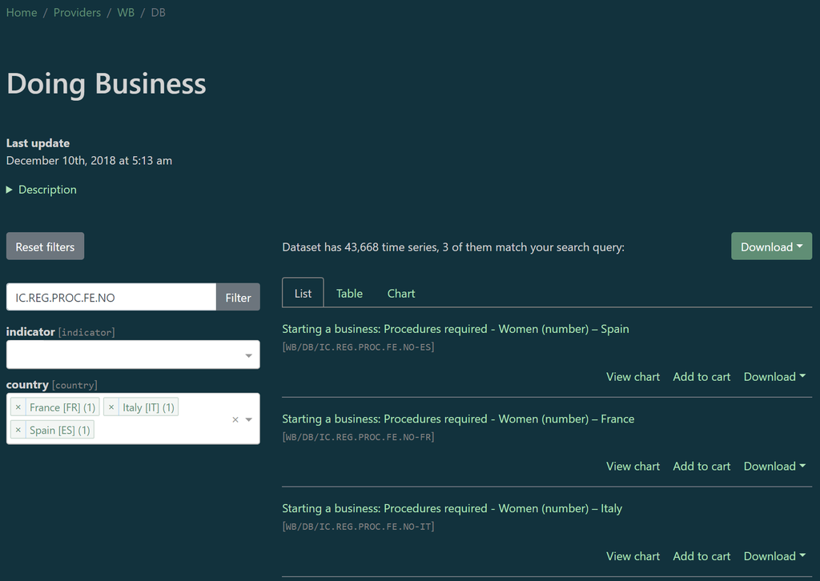

- click on “*Copy API link*” in the menu of the “*Download*” button,

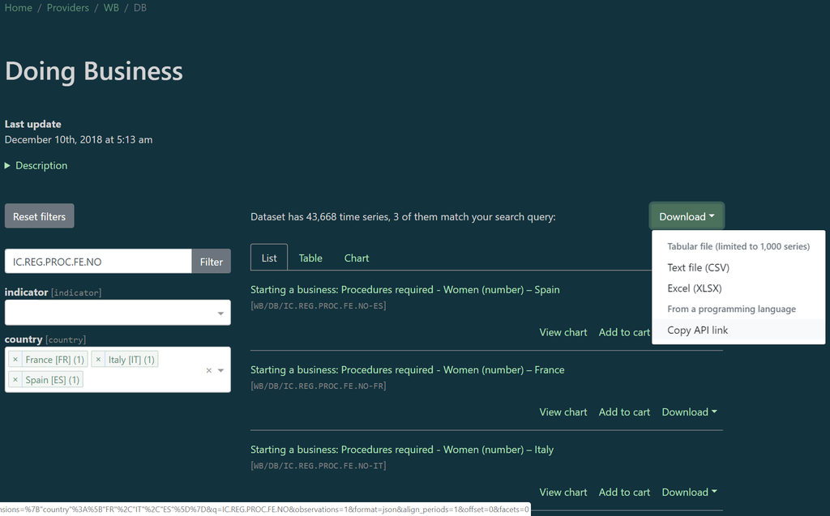

- use the `rdb_by_api_link` function such as below.

```r
df <- rdb_by_api_link("https://api.db.nomics.world/v22/series/WB/DB?dimensions=%7B%22country%22%3A%5B%22FR%22%2C%22IT%22%2C%22ES%22%5D%7D&q=IC.REG.PROC.FE.NO&observations=1&format=json&align_periods=1&offset=0&facets=0") %>%
  filter(!is.na(value))
```

| provider_code | dataset_code | dataset_name | series_code | series_name | original_period | period | value | @frequency | indexed_at | observations_attributes | country | indicator |
| --- | --- | --- | --- | --- | --- | --- | --- | --- | --- | --- | --- | --- |
| WB | DB | Doing Business | IC.REG.PROC.FE.NO-FR | Starting a business: Procedures required - Women (number) – France | 2004 | 2004-01-01 | 8 | annual | 2018-12-10T04:14:34Z | ATTRIBUTE, | FR | IC.REG.PROC.FE.NO |
| WB | DB | Doing Business | IC.REG.PROC.FE.NO-IT | Starting a business: Procedures required - Women (number) – Italy | 2004 | 2004-01-01 | 9 | annual | 2018-12-10T04:14:34Z | ATTRIBUTE, | IT | IC.REG.PROC.FE.NO |
| WB | DB | Doing Business | IC.REG.PROC.FE.NO-ES | Starting a business: Procedures required - Women (number) – Spain | 2004 | 2004-01-01 | 10 | annual | 2018-12-10T04:14:34Z | ATTRIBUTE, | ES | IC.REG.PROC.FE.NO |
| WB | DB | Doing Business | IC.REG.PROC.FE.NO-FR | Starting a business: Procedures required - Women (number) – France | 2005 | 2005-01-01 | 5 | annual | 2018-12-10T04:14:34Z | ATTRIBUTE, | FR | IC.REG.PROC.FE.NO |
| WB | DB | Doing Business | IC.REG.PROC.FE.NO-IT | Starting a business: Procedures required - Women (number) – Italy | 2005 | 2005-01-01 | 9 | annual | 2018-12-10T04:14:34Z | ATTRIBUTE, | IT | IC.REG.PROC.FE.NO |
| WB | DB | Doing Business | IC.REG.PROC.FE.NO-ES | Starting a business: Procedures required - Women (number) – Spain | 2005 | 2005-01-01 | 10 | annual | 2018-12-10T04:14:34Z | ATTRIBUTE, | ES | IC.REG.PROC.FE.NO |
| WB | DB | Doing Business | IC.REG.PROC.FE.NO-FR | Starting a business: Procedures required - Women (number) – France | 2006 | 2006-01-01 | 5 | annual | 2018-12-10T04:14:34Z | ATTRIBUTE, | FR | IC.REG.PROC.FE.NO |
| WB | DB | Doing Business | IC.REG.PROC.FE.NO-IT | Starting a business: Procedures required - Women (number) – Italy | 2006 | 2006-01-01 | 9 | annual | 2018-12-10T04:14:34Z | ATTRIBUTE, | IT | IC.REG.PROC.FE.NO |
| WB | DB | Doing Business | IC.REG.PROC.FE.NO-ES | Starting a business: Procedures required - Women (number) – Spain | 2006 | 2006-01-01 | 10 | annual | 2018-12-10T04:14:34Z | ATTRIBUTE, | ES | IC.REG.PROC.FE.NO |
| WB | DB | Doing Business | IC.REG.PROC.FE.NO-FR | Starting a business: Procedures required - Women (number) – France | 2007 | 2007-01-01 | 5 | annual | 2018-12-10T04:14:34Z | ATTRIBUTE, | FR | IC.REG.PROC.FE.NO |

[output cut: 38 more lines]

[figure not shown]

```r
ggplot(df, aes(x = period, y = value, color = series_name)) +
  geom_step(size = 2) +
  dbnomics()
```

# 6 Fetch time series from the cart

On the cart page of the [DBnomics website](https://db.nomics.world), click on “*Copy API link*” and copy-paste it as an argument of the `rdb_by_api_link` function. Please note that when you update your cart, you have to copy this link again, because the link itself contains the ids of the series in the cart.

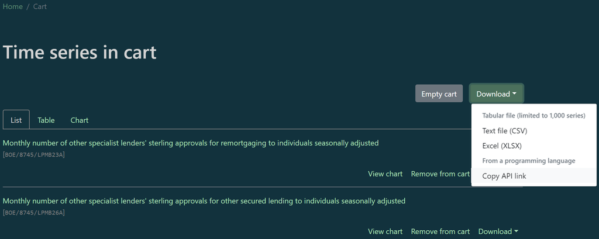

```r
df <- rdb_by_api_link("https://api.db.nomics.world/v22/series?series_ids=BOE%2F8745%2FLPMB23A%2CBOE%2F8745%2FLPMB26A&observations=1&format=json&align_periods=1") %>%
  filter(!is.na(value))
```

| provider_code | dataset_code | dataset_name | series_code | series_name | original_period | period | value | @frequency | freq | indexed_at |
| --- | --- | --- | --- | --- | --- | --- | --- | --- | --- | --- |
| BOE | 8745 | Monthly lending secured on dwellings: approvals | LPMB26A | Monthly number of other specialist lenders' sterling approvals for other secured lending to individuals seasonally adjusted | 1999-01 | 1999-01-01 | 170 | monthly | M | 2019-01-05T05:24:45Z |
| BOE | 8745 | Monthly lending secured on dwellings: approvals | LPMB23A | Monthly number of other specialist lenders' sterling approvals for remortgaging to individuals seasonally adjusted | 1999-01 | 1999-01-01 | 946 | monthly | M | 2019-01-05T05:24:45Z |
| BOE | 8745 | Monthly lending secured on dwellings: approvals | LPMB26A | Monthly number of other specialist lenders' sterling approvals for other secured lending to individuals seasonally adjusted | 1999-02 | 1999-02-01 | 506 | monthly | M | 2019-01-05T05:24:45Z |
| BOE | 8745 | Monthly lending secured on dwellings: approvals | LPMB23A | Monthly number of other specialist lenders' sterling approvals for remortgaging to individuals seasonally adjusted | 1999-02 | 1999-02-01 | 1570 | monthly | M | 2019-01-05T05:24:45Z |
| BOE | 8745 | Monthly lending secured on dwellings: approvals | LPMB26A | Monthly number of other specialist lenders' sterling approvals for other secured lending to individuals seasonally adjusted | 1999-03 | 1999-03-01 | 544 | monthly | M | 2019-01-05T05:24:45Z |
| BOE | 8745 | Monthly lending secured on dwellings: approvals | LPMB23A | Monthly number of other specialist lenders' sterling approvals for remortgaging to individuals seasonally adjusted | 1999-03 | 1999-03-01 | 2093 | monthly | M | 2019-01-05T05:24:45Z |
| BOE | 8745 | Monthly lending secured on dwellings: approvals | LPMB26A | Monthly number of other specialist lenders' sterling approvals for other secured lending to individuals seasonally adjusted | 1999-04 | 1999-04-01 | 1220 | monthly | M | 2019-01-05T05:24:45Z |
| BOE | 8745 | Monthly lending secured on dwellings: approvals | LPMB23A | Monthly number of other specialist lenders' sterling approvals for remortgaging to individuals seasonally adjusted | 1999-04 | 1999-04-01 | 1849 | monthly | M | 2019-01-05T05:24:45Z |
| BOE | 8745 | Monthly lending secured on dwellings: approvals | LPMB26A | Monthly number of other specialist lenders' sterling approvals for other secured lending to individuals seasonally adjusted | 1999-05 | 1999-05-01 | 1187 | monthly | M | 2019-01-05T05:24:45Z |
| BOE | 8745 | Monthly lending secured on dwellings: approvals | LPMB23A | Monthly number of other specialist lenders' sterling approvals for remortgaging to individuals seasonally adjusted | 1999-05 | 1999-05-01 | 1874 | monthly | M | 2019-01-05T05:24:45Z |

[output cut: 468 more lines]

[figure not shown]

```r
ggplot(df, aes(x = period, y = value, color = series_name)) +
  geom_line(size = 2) +
  scale_y_continuous(labels = function(x) { format(x, big.mark = " ") }) +
  dbnomics()
```

# 7 Appendix

## 7.1 Connection error `Could not resolve host`

When using the functions `rdb` or `rdb_by_api_link`, you may come across the following error :

```r
Error in open.connection(con, "rb") :
  Could not resolve host: api.db.nomics.world
```

This error is due to a fail of the function `fromJSON`. To get round this situation, you can use the `readLines` function before the `fromJSON` function by setting an option of the package :

```r
options(rdbnomics.use_readLines = TRUE)

df1 <- rdb(ids = 'AMECO/ZUTN/EA19.1.0.0.0.ZUTN')

df2 <- rdb(ids = c('AMECO/ZUTN/EA19.1.0.0.0.ZUTN', 'AMECO/ZUTN/DNK.1.0.0.0.ZUTN'))
```

```r
df1 <- rdb(ids = 'AMECO/ZUTN/EA19.1.0.0.0.ZUTN', use_readLines = TRUE)

df2 <- rdb(
  ids = c('AMECO/ZUTN/EA19.1.0.0.0.ZUTN', 'AMECO/ZUTN/DNK.1.0.0.0.ZUTN'),
  use_readLines = TRUE
)
```

## 7.2 ggplot2 function `dbnomics()` used in the vignette

We show the function `dbnomics()` as an information. It’s not implemented in the package.

```r
dbnomics <- function(legend_title = "Code") {
  list(
    scale_x_date(expand = c(0, 0)),
    xlab(""),
    ylab(""),
    guides(color = guide_legend(title = legend_title)),
    theme_bw(),
    theme(
      legend.position = "bottom", legend.direction = "vertical",
      legend.background = element_rect(fill = "transparent", colour = NA),
      legend.key = element_blank(),
      panel.background = element_rect(fill = "transparent", colour = NA),
      plot.background = element_rect(fill = "transparent", colour = NA),
      legend.title = element_blank()
    ),
    annotate(
      geom = "text", label = "DBnomics",
      x = structure(Inf, class = "Date"), y = -Inf,
      hjust = 1.1, vjust = -0.4, col = "grey",
      fontface = "italic"
    )
  )
}
```

[^1]: CEPREMAP
[^2]: Banque de France